# Glass Slides Data Exploration — Chapter 3

Kendra Walters

11/11/2020

# Hello from glass slides!

This page gives the most promising exploratory graphs/stats from the Landscape Dispersal project.

First off, we are answering our *first* question in our project -

### Do different ecosystems (plant communities) have different dispersal communities?

Check it out below, but the answer is YES!! There are DEFINITELY different taxa dispersing in the grassland than the shrubland.

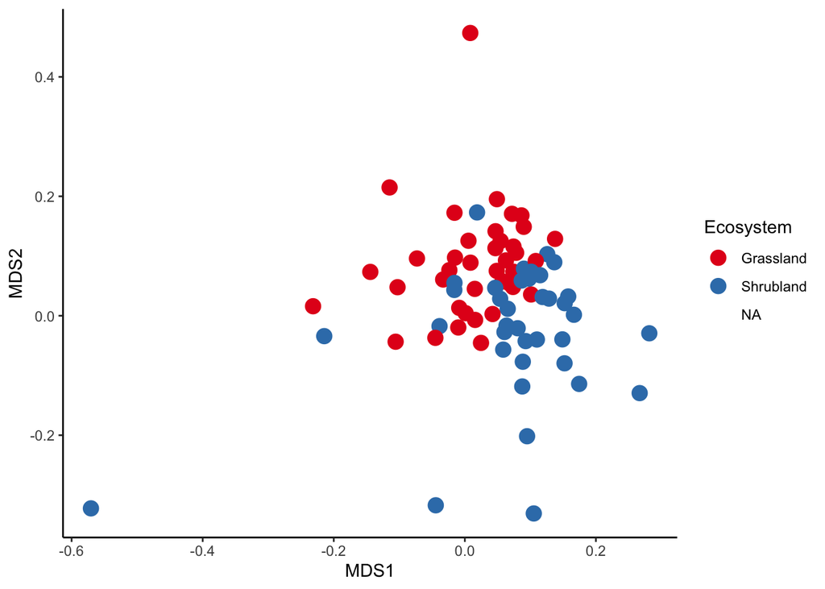

```
Call:
adonis(formula = tmp ~ Ecosystem, data = just_dispersal)

Permutation: free
Number of permutations: 999

Terms added sequentially (first to last)

          Df SumsOfSqs MeanSqs F.Model      R2 Pr(>F)
Ecosystem  1    0.7964 0.79644  2.1389 0.02809  0.001 ***
Residuals 74   27.5545 0.37236         0.97191
Total     75   28.3509                 1.00000
---
Signif. codes:  0 '***' 0.001 '**' 0.01 '*' 0.05 '.' 0.1 ' ' 1
```

### Second, how far are microorganisms dispersing?

This gives us a sense of the dispersal kernal. We hypothesize that samples closer together (but still across the ecosystem boundary) have more similar dispersal communities than samples farther apart. However, as you can see, this relatively easy analysis does not support that hypothesis, likely because the analysis method here reduces the sample size by only comparing every sample to one other sample.

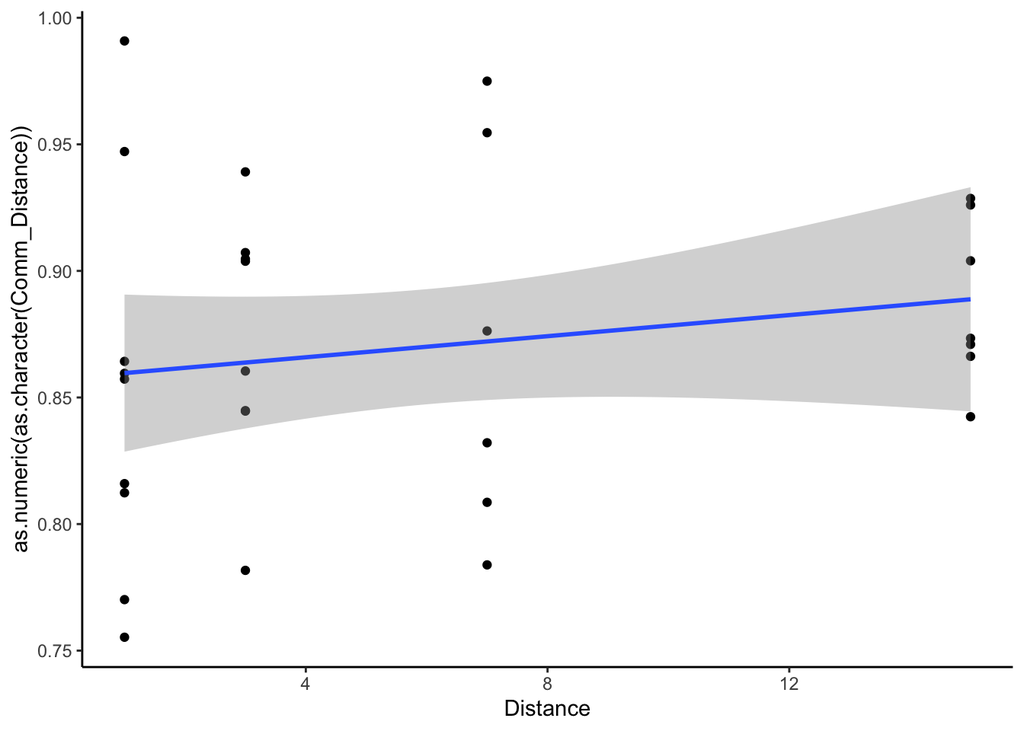

```
Call:
lm(formula = as.numeric(as.character(Comm_Distance)) ~ Distance,
    data = dist.df)

Residuals:
      Min        1Q    Median        3Q       Max
-0.104345 -0.042750 -0.002857  0.039980  0.131212

Coefficients:
            Estimate Std. Error t value Pr(>|t|)
(Intercept) 0.857548   0.016618   51.60   <2e-16 ***
Distance    0.002083   0.002061    1.01    0.321
---
Signif. codes:  0 '***' 0.001 '**' 0.01 '*' 0.05 '.' 0.1 ' ' 1

Residual standard error: 0.0608 on 28 degrees of freedom
  (18 observations deleted due to missingness)
Multiple R-squared:  0.03518,   Adjusted R-squared:  0.0007265
F-statistic: 1.021 on 1 and 28 DF,  p-value: 0.3209
```

The next option is to try a partial mantel test because, what we want to test, is if geographic distance and community dissimilarity are correlated when differences (variation) caused by different ecosystems is taken out. We can also graph geographic distance v community dissimilarity for pairwise samples from different ecosystems to see if there is a recognizable dispersal kernel. We just can’t run a regression on those pairwise samples because the samples are not independent from one another.

First we will look at that dot plot graph to see if there is any recognizable dispersal kernel. Then the partial mantel test.

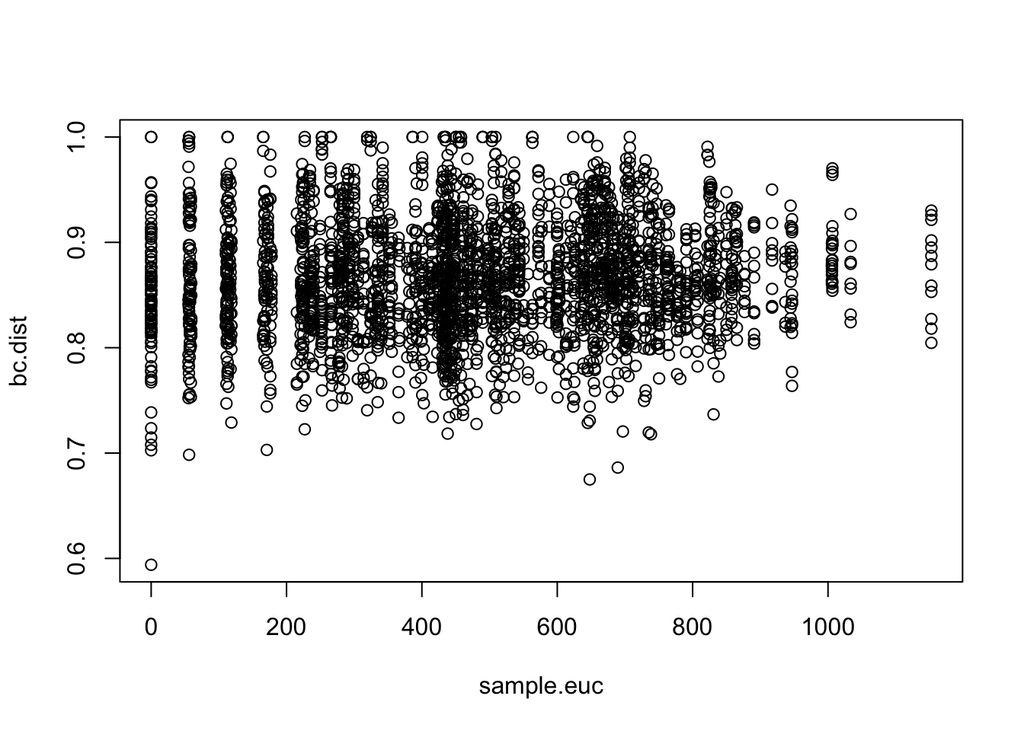

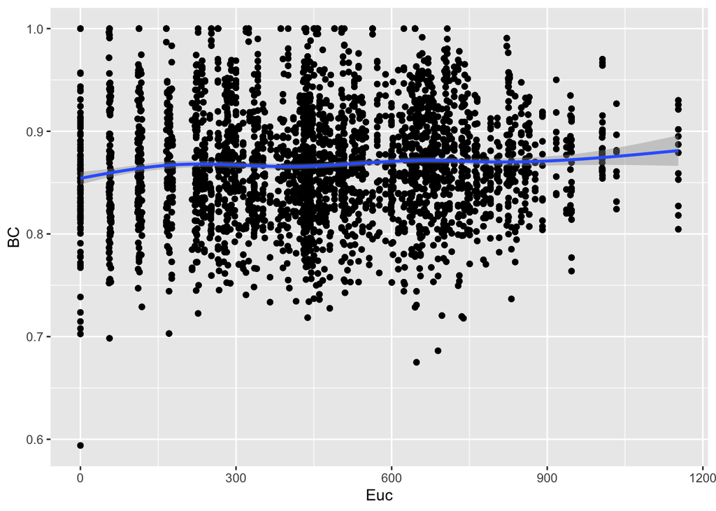

[output not shown]

```
$MantelR
       r12        r13        r23      r12.3      r13.2
0.05755367 0.12052004 0.25138261 0.02836813 0.10975252

$p
[1] 0.131868132 0.001998002 0.001998002 0.287712288 0.001998002

$call
[1] "partial.mantel.test(M1 = as.matrix(bc.dist), M2 = as.matrix(sample.euc), "
[2] "    M3 = as.matrix(eco.dist), resamp = 1000)"

attr(,"class")
[1] "partial.Mantel"
```

I’ve reported here the partial mantel test with the spearman correlation, but the same trends were found using the pearson and kendall method.

All of these tests show us that the dispersal kernel is likely really small, since we aren’t picking up any relationship between geographic distance and dispersal community.

### Testing the influence of surrounding plant composition

Piggybacking on analyzing dispersal kernels, we are going to test the correlation between the plant communities and/or geographic distance and dispersal communities. Because we previously discovered that geographic distance and dispersal communities do not have a significant relationship, this strengthens my hypothesis that - plant communities will have a stronger correlation to dispersal communities than geographic distance.

[output not shown]

```
$MantelR
       r12        r13        r23      r12.3      r13.2
0.05755367 0.13749509 0.25791871 0.02308395 0.12715671

$p
[1] 0.148851149 0.035964036 0.001998002 0.323676324 0.050949051

$call
[1] "partial.mantel.test(M1 = as.matrix(bc), M2 = as.matrix(sample.euc), "
[2] "    M3 = as.matrix(sample.plants.bc), resamp = 1000)"

attr(,"class")
[1] "partial.Mantel"
```